# Task 3: Santa Barbara Urchins

Sophia Leiker

10/28/2021

# Setup

- Attaching packages
- Setting code chunk options

```r
knitr::opts_chunk$set(echo = TRUE,warning = FALSE, message = FALSE)

#Attaching packages
library(here)
library(tidyverse)
library(janitor)
library(kableExtra)
library(lubridate)
```

# Overview

In this data analysis, I am using data for red and purple urchins observed at 5 sites along the Santa Barbara coast to asses size comparisons, explore purple urchin counts by site and year, and make a finalized graph to visualize results.

Data Citation: Reed, D. 2020. SBC LTER: Reef: Long-term experiment: Kelp removal: Urchin size frequency distribution ver 20. Environmental Data Initiative. https://doi.org/10.6073/pasta/5a1e9ef03aa47bd2225c0bb98a02a63b.

# Section 1: Size Comparisons for Purple and Red Urchins

### Reading in the data

- Reading in the urchins data set using here()
- Cleaning up the column names to lower snake

```r
urchins <- read_csv(here("data", "urchins.csv"), show_col_types = FALSE)

#Cleaning up the column names
urchins <- clean_names(urchins)
```

### Part 1: Data Visualization

- Comparing distribution of sizes between purple and red urchins with a histogram
- Reducing number of bins from ~30 to 10

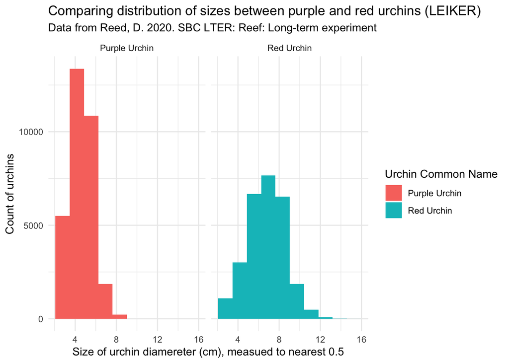

```r
ggplot(data = urchins, aes(x = size, fill = common_name)) +
  geom_histogram(bins = 10) +
  facet_wrap(~common_name) +
  labs(x = "Size of urchin diamereter (cm), measued to nearest 0.5", y = "Count of urchins", title = "Comparing distribution of sizes between purple and red urchins (LEIKER)", subtitle = "Data from Reed, D. 2020. SBC LTER: Reef: Long-term experiment") +
  theme_minimal() +
  guides(fill = guide_legend(title = "Urchin Common Name"))
```

Figure 1: Comparing distributions of sea urchin sizes between purple sea urchins and red sea urchins with size defined as sea urchin diameter measure in cm to the nearest 0.5

### Part 2: Descriptive Statistics Table

- Creating finalized summary table that contains the following:Mean, Median, Standard deviation, Sample size
- Rounding to only one decimal point because the measurements were taken were measured to the nearest 0.5

```r
urchins_stats <- urchins %>%
  group_by(common_name) %>%
  summarize(urchin_mean = round(mean(size), 1),
            urchin_median = round(median(size), 1),
            urchin_sd = round(sd(size),1),
            urchin_sample_size = n())
```

Updating Column Names in Urchin Stats

```r
urchins_stats <- rename(urchins_stats, "Common Name" = "common_name")
urchins_stats <- rename(urchins_stats, "Urchin Size Mean (cm)" = "urchin_mean")
urchins_stats <- rename(urchins_stats, "Urchin Size Median (cm)" = "urchin_median")
urchins_stats <- rename(urchins_stats, "Urchin Size Standard Deviation (cm)" = "urchin_sd")
urchins_stats <- rename(urchins_stats, "Sample Size" = "urchin_sample_size")
```

```r
urchins_stats %>%
  kbl(caption = "Table 1: Sea Urchin Size Stats: Purple Urchins vs Red Urchins") %>%
  kable_styling(full_width = F, html_font = "Cambria")
```

Table 1: Sea Urchin Size Stats: Purple Urchins vs Red Urchins

| Common Name | Urchin Size Mean (cm) | Urchin Size Median (cm) | Urchin Size Standard Deviation (cm) | Sample Size |
| --- | --- | --- | --- | --- |
| Purple Urchin | 4.5 | 4.5 | 1.2 | 31805 |
| Red Urchin | 6.8 | 7.0 | 1.9 | 27408 |

### Part 3: Overall takeaways

We can see that overall the mean urchin size for red urchins are larger than purple urchins. The actual difference between the means is 2.3cm.

Their standard differences (the measure of spread/dispersion of the sample) differ in that the purple urchin spread is lower (SD of 1.2) than the spread of the red urchin data (SD of 1.9).

# Section 2: Exploring Purple Urchin Counts by Site and Year

### Part 1: Subset of Urchins data

- Filtering only for purple urchins, converting date to class “Date”, creating new column that only contains year, creating new column that has full name for each of the 5 sites

```r
purple_urchins <- urchins %>%
  filter(common_name == "Purple Urchin") %>% #checked using unique(purple_urchins$common_name) in console
  mutate(date = mdy(date)) %>% #checking using class(purple_urchins$date)
  mutate(year = year(date)) %>%
  mutate(site_full = case_when(
    site == "NAPL" ~ "Naples Reef",
    site == "AQUE" ~ "Arroyo Quemado Reef",
    site == "CARP" ~ "Carpinteria Reef",
    site == "MOHK" ~ "Mohawk Reef",
    site == "IVEE" ~ "Isla Vista Reef"
  ))
```

### Part 2: Creating a Table for Total Number of Purple Urchins

- Table for total number of purple urchins observed by site and year
- Doesn’t need to appear in knitted doc

```r
total_purple <- purple_urchins %>%
  group_by(site_full, year) %>%
  summarize(total = n()) #used summarize here so I could check and make sure the output makes sense

#Checking output to make sure it makes sense
head(total_purple)
```

```
## # A tibble: 6 × 3
## # Groups:   site_full [1]
##   site_full            year total
##   <chr>               <dbl> <int>
## 1 Arroyo Quemado Reef  2008    67
## 2 Arroyo Quemado Reef  2009   926
## 3 Arroyo Quemado Reef  2010   921
## 4 Arroyo Quemado Reef  2011   887
## 5 Arroyo Quemado Reef  2012   764
## 6 Arroyo Quemado Reef  2013   434
```

### Part 3: Graphing counts of Purple Urchins

- Making finalized graph of counts of purple urchins recorded at each site over time for years in the the study

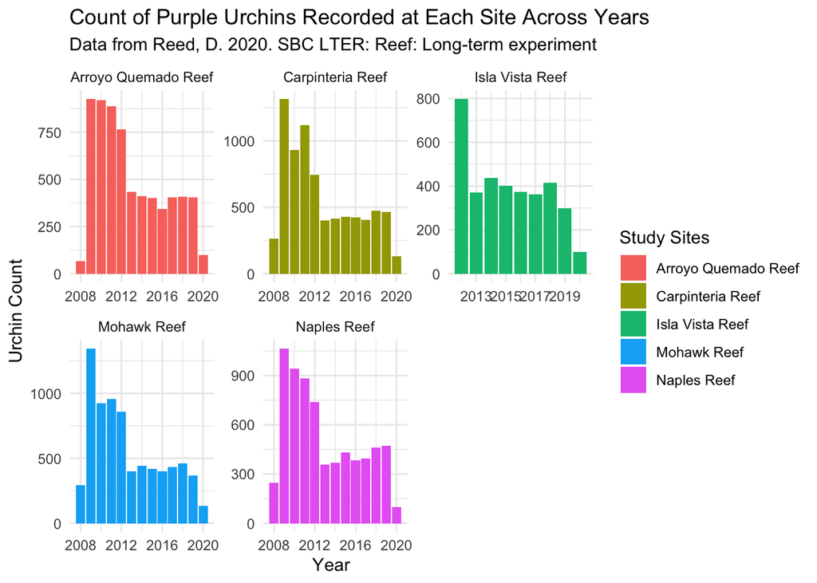

```r
ggplot(data = total_purple, aes(x= year, y = total, fill = site_full)) +
  geom_col() +
  facet_wrap(~ site_full, scales = "free") +
  labs(x = "Year", y = "Urchin Count", title = "Count of Purple Urchins Recorded at Each Site Across Years", subtitle = "Data from Reed, D. 2020. SBC LTER: Reef: Long-term experiment") +
  theme_minimal() +
  guides(fill = guide_legend(title = "Study Sites"))
```

Figure 2: Count of purple urchins recorded at each site across all the years included in the study

### Part 4: Analysis

In general, you can see a trend of purple urchin counts dropping from 2008 to 2020. One thing you would have to take into account is the influence of the control vs annual treatments. The alteration of the giant kelp could be a driver in the drop of purple urchin counts in that there is potential that the annual treatments could cause a decline in urchin counts. Another thing that you would have to take into account is that every time counts were taken, that the same exact area was assessed, at the same tidal time, and that they went out the same amount of times. A drop in urchin counts could reflect simply that their data collection practices were not consistent. Climate could also effect urchin counts as it is always an influence on population dynamics.

# END TASK 3